# Понятия о теориях Луны Адамса и Хиля

Леонард Эйлер (с изменениями от В. М. Хайтова)

03 11 2020

Внимание!

Выполняя это задание вы должны стремиться к тому, чтобы все элементы документа, который вы производите, были бы в точност такими же, как в исходном html-документе.

Пусть Рис. 2.1 представляет положение Солнца $S$, Земли $T$ и Луны $L$, и пусть $\Theta$ есть центр тяжести Земли и Луны. Делаем следующие обозначения (Табл. 1).

Таблица 1. Обозначения, принятые в работе

$$\begin{matrix}
Масса \ Солнца & S \\
Масса \ Земли & T \\
Масса \ Луны & L \\
\end{matrix}$$
______________________________

**NB!** Эта таблица вставлена как формула. Подумайте, как это сделать.

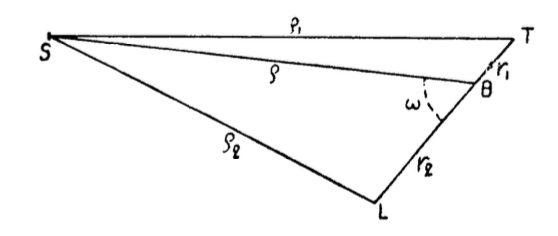

Рисунок 2.1. Схема расположения небесных тел

Расстояние:
$$S\Theta = \rho \text{; } ST=\rho_1 \text{; } SL = \rho_2 \text{; } TL = \gamma$$

Тогда будет:

$$T\Theta = \gamma_1 = \frac{L}{T+L}\cdot\gamma \\
L\Theta = \gamma_2 = \frac{T}{T+L}\cdot\gamma$$

Составим теперь выражения ускорений, которые эти тела сообщают друг другу.

Солнце $S$ сообщает ускорения:

$$\begin{matrix}
Земле: & f\cdot\dfrac{S}{\rho_{1}^{2}} & по \ направлению & TS \\
\\
Луне:& f\cdot\dfrac{S}{\rho_{2}^{2}} & по \ направлению & LS \\
\end{matrix}$$

поэтому ускорения точки $\Theta$ относительно точки $S$ будут:

$$\omega_1 = f \cdot \dfrac{S+T+L}{T+L} \cdot \dfrac{T}{\rho_{1}^{2}}
\\
\omega_2 = f \cdot \dfrac{S+T+L}{T+L} \cdot \dfrac{L}{\rho_{2}^{2}}$$

Заменив $\gamma_1$ и $\gamma_2$ их выражениями, имеем:

- $W_{1} = f \cdot \dfrac{S+T+L}{T+L} \cdot \rho \cdot \left[\dfrac{T}{\rho_{1}^{3}} + \dfrac{T}{\rho_{2}^{3}} \right]$
- $W_{2} = f \cdot \dfrac{S+T+L}{(T+L)^2} \cdot T \cdot L \cdot \gamma \left[\dfrac{1}{\rho_{1}^{3}} - \dfrac{1}{\rho_{2}^{3}} \right]$

Но

- $\rho_{1}^{2} = \rho^2 + 2\rho \cdot \dfrac{L}{T+L} \cdot \gamma \cos \omega + \left(\dfrac{L}{T+L} \cdot \gamma \right)^2$
- $\rho_{2}^{2} = \rho^2 + 2\rho \cdot \dfrac{L}{T+L} \cdot \gamma \cos \omega + \left(\dfrac{L}{T+L} \cdot \gamma \right)^2$

следовательно

$$\begin{aligned}
\dfrac{1}{\rho_{1}^{3}} & = \dfrac{1}{\rho^3} \left[1 + 3 \dfrac{L}{T+L} \cos \omega + \left(\dfrac{L}{T+L}\gamma \right)^2 \left(-\dfrac{3}{2} + \dfrac{15}{2} \cos^2 \omega \right) + \dots \right] \\
\dfrac{1}{\rho_{2}^{3}} & = \dfrac{1}{\rho^3} \left[1 + 3 \dfrac{T}{T+L} \cos \omega + \left(\dfrac{L}{T+L}\gamma \right)^2 \left(-\dfrac{3}{2} + \dfrac{15}{2} \cos^2 \omega \right) + \dots \right]
\end{aligned}$$

Подставляя эти выражения, имеем:

$$\begin{aligned}
W_1 = f \cdot \dfrac{S+T+L}{\rho{^2}} \left[1+\dfrac{T \cdot L}{(T+L)^2} \cdot \dfrac{\gamma^2}{\rho^2} \left(-\dfrac{3}{2} + \dfrac{15}{2} \cos^2 \omega \right) + \dots \right] \\
\\
\\
W_2 = f \cdot \dfrac{S+T+L}{\rho{^2}} \left[-3 \cdot \dfrac{T \cdot L}{(T+L)^2} \cdot \dfrac{\gamma^2}{\rho^2} \cos \omega + \dots \right]
\end{aligned}$$